# Project: Investigate a Dataset - Medical Appointment No Shows

- Introduction
- Data Wrangling
- Exploratory Data Analysis
- Conclusions

## Data Overview

The dataset includes **14 variables**, each representing different aspects of patient appointments and demographics. Below is a brief description of each column:

### Question(s) for Analysis

1- What factors influence whether a patient will miss their scheduled medical appointment?

2- How does age affect the probability of missing an appointment?

```python
import pandas as pd
import numpy as np
import matplotlib.pyplot as plt
import seaborn as sns
```

## Data Wrangling

### Data Cleaning

```python
# Load the dataset
df = pd.read_csv("medical_appointment_no_shows.csv")
df.shape
```

```
(110527, 14)
```

The dataset consists of **110,527** recorde (rows) and **14 columns**

```python
df.head()
```

|  | PatientId | AppointmentID | Gender | ScheduledDay | AppointmentDay | Age | Neighbourhood | Scholarship | Hipertension | Diabetes | Alcoholism | Handcap | SMS_received | No-show |
| --- | --- | --- | --- | --- | --- | --- | --- | --- | --- | --- | --- | --- | --- | --- |
| 0 | 2.987250e+13 | 5642903 | F | 2016-04-29T18:38:08Z | 2016-04-29T00:00:00Z | 62 | JARDIM DA PENHA | 0 | 1 | 0 | 0 | 0 | 0 | No |
| 1 | 5.589978e+14 | 5642503 | M | 2016-04-29T16:08:27Z | 2016-04-29T00:00:00Z | 56 | JARDIM DA PENHA | 0 | 0 | 0 | 0 | 0 | 0 | No |
| 2 | 4.262962e+12 | 5642549 | F | 2016-04-29T16:19:04Z | 2016-04-29T00:00:00Z | 62 | MATA DA PRAIA | 0 | 0 | 0 | 0 | 0 | 0 | No |
| 3 | 8.679512e+11 | 5642828 | F | 2016-04-29T17:29:31Z | 2016-04-29T00:00:00Z | 8 | PONTAL DE CAMBURI | 0 | 0 | 0 | 0 | 0 | 0 | No |
| 4 | 8.841186e+12 | 5642494 | F | 2016-04-29T16:07:23Z | 2016-04-29T00:00:00Z | 56 | JARDIM DA PENHA | 0 | 1 | 1 | 0 | 0 | 0 | No |

Here we can take an overview of the data shape and values

```python
df.info()
```

```
<class 'pandas.core.frame.DataFrame'>
RangeIndex: 110527 entries, 0 to 110526
Data columns (total 14 columns):
 #   Column          Non-Null Count   Dtype
---  ------          --------------   -----
 0   PatientId       110527 non-null  float64
 1   AppointmentID   110527 non-null  int64
 2   Gender          110527 non-null  object
 3   ScheduledDay    110527 non-null  object
 4   AppointmentDay  110527 non-null  object
 5   Age             110527 non-null  int64
 6   Neighbourhood   110527 non-null  object
 7   Scholarship     110527 non-null  int64
 8   Hipertension    110527 non-null  int64
 9   Diabetes        110527 non-null  int64
 10  Alcoholism      110527 non-null  int64
 11  Handcap         110527 non-null  int64
 12  SMS_received    110527 non-null  int64
 13  No-show         110527 non-null  object
dtypes: float64(1), int64(8), object(5)
memory usage: 11.8+ MB
```

#### 1. Data Types and Memory Usage

- The dataset consists of **110,527 rows and 14 columns**, using **11.8+ MB** of memory.
- The data includes **a mix of numerical (`int64`, `float64`) and (`object`) types**.
- **No missing values** are present; all columns have 110,527 non-null entries.

#### 2. Necessary Data Type Conversions

- `PatientId` is stored as **float64**, but since IDs don’t require decimals, it should be converted to **int64**.
- `ScheduledDay` and `AppointmentDay` are **object** types instead of datetime. They need to be converted for proper date analysis.
- **Many categorical variables** are stored as `object` (strings), but should be converted to `category` type to optimize memory usage.

```python
df.describe()
```

|  | PatientId | AppointmentID | Age | Scholarship | Hipertension | Diabetes | Alcoholism | Handcap | SMS_received |
| --- | --- | --- | --- | --- | --- | --- | --- | --- | --- |
| count | 1.105270e+05 | 1.105270e+05 | 110527.000000 | 110527.000000 | 110527.000000 | 110527.000000 | 110527.000000 | 110527.000000 | 110527.000000 |
| mean | 1.474963e+14 | 5.675305e+06 | 37.088874 | 0.098266 | 0.197246 | 0.071865 | 0.030400 | 0.022248 | 0.321026 |
| std | 2.560949e+14 | 7.129575e+04 | 23.110205 | 0.297675 | 0.397921 | 0.258265 | 0.171686 | 0.161543 | 0.466873 |
| min | 3.921784e+04 | 5.030230e+06 | -1.000000 | 0.000000 | 0.000000 | 0.000000 | 0.000000 | 0.000000 | 0.000000 |
| 25% | 4.172614e+12 | 5.640286e+06 | 18.000000 | 0.000000 | 0.000000 | 0.000000 | 0.000000 | 0.000000 | 0.000000 |
| 50% | 3.173184e+13 | 5.680573e+06 | 37.000000 | 0.000000 | 0.000000 | 0.000000 | 0.000000 | 0.000000 | 0.000000 |
| 75% | 9.439172e+13 | 5.725524e+06 | 55.000000 | 0.000000 | 0.000000 | 0.000000 | 0.000000 | 0.000000 | 1.000000 |
| max | 9.999816e+14 | 5.790484e+06 | 115.000000 | 1.000000 | 1.000000 | 1.000000 | 1.000000 | 4.000000 | 1.000000 |

The **minimum age is -1**, which is **impossible** and should be corrected

```python
df.nunique()
```

```
PatientId          62299
AppointmentID     110527
Gender                 2
ScheduledDay      103549
AppointmentDay        27
Age                  104
Neighbourhood         81
Scholarship            2
Hipertension           2
Diabetes               2
Alcoholism             2
Handcap                5
SMS_received           2
No-show                2
dtype: int64
```

- **62,299 unique patients** (`PatientId`), indicating that some patients have multiple appointments.
- **110,527 unique appointments** (`AppointmentID`), confirming each row represents an individual appointment.
- **81 different neighborhoods**, meaning appointments were scheduled across multiple locations.
- **Categorical Variables to Convert**:
  - `Gender` – Binary category (Male/Female).
  - `Neighbourhood` – 81 unique values, representing appointment locations.
  - `Scholarship`, `Hypertension`, `Diabetes`, `Alcoholism`, `SMS_received`, `No-show` – All **binary** (0 = No, 1 = Yes).
  - `Handcap` – Contains **five unique values (0, 1, 2, 3, 4)**

```python
df['Handcap'].value_counts()
```

```
0    108286
1      2042
2       183
3        13
4         3
Name: Handcap, dtype: int64
```

The majority of patients (**108,286**) have **no disability (`0`)**, while a smaller number have disabilities ranging from **1 to 4**. Since higher values are rare, we might consider grouping them into a **binary category** (`0 = No disability`, `1+ = Has disability`).

```python
df['Age'].value_counts()
```

```
 0      3539
 1      2273
 52     1746
 49     1652
 53     1651
        ...
 115       5
 100       4
 102       2
 99        1
-1         1
Name: Age, Length: 104, dtype: int64
```

- The dataset contains **104 unique age values**, ranging from **-1 to 115**.
- The most common age is **0 (3,539 occurrences)**, which likely represents newborns or infants.
- Ages **1, 49, 52, and 53** are also frequent, each with over **1,500 occurrences**.
- The presence of **negative values (-1)** is an anomaly and should be removed or corrected.

Dataset for analysis, the following cleaning steps are required:

1. **Convert date columns (`ScheduledDay`, `AppointmentDay`) to datetime format** for easier analysis.

```python
# Convert date columns to datetime format
df["ScheduledDay"] = pd.to_datetime(df["ScheduledDay"])
df["AppointmentDay"] = pd.to_datetime(df["AppointmentDay"])
```

2. **Change `PatientId` from `float64` to `int64`**, as patient IDs do not require decimal points.

```python
# Convert PatientId to integer
df["PatientId"] = df["PatientId"].astype("int64")
```

3. **Convert categorical variables (`Gender`, `Neighbourhood`, etc.) to category type** for optimized performance.

#### Categorical Variables

The following columns contain categorical data and should be converted to the **category** data type for optimized storage and analysis:

1. **Gender** – Binary category (Male/Female).
2. **Neighbourhood** – Contains **81 unique values**, representing different locations.
3. **Scholarship** – Binary (0 = No, 1 = Yes).
4. **Hypertension** – Binary (0 = No, 1 = Yes).
5. **Diabetes** – Binary (0 = No, 1 = Yes).
6. **Alcoholism** – Binary (0 = No, 1 = Yes).
7. **Handcap** – Multiple levels (0, 1, 2, 3, 4) but can be simplified.
8. **SMS_received** – Binary (0 = No, 1 = Yes).
9. **No-show** – Binary (0 = Show, 1 = No-show), though it might be stored as a string and needs conversion.

```python
# Convert categorical variables to category type
categorical_cols = ["Gender","Handcap", "Neighbourhood", "Scholarship", "Hipertension", "Diabetes", "Alcoholism", "SMS_received", "No-show"]
df[categorical_cols] = df[categorical_cols].astype("category")
```

4. **Handle the incorrect `Age` values** by removing or correcting negative values.

```python
# Handle incorrect age values (remove negative ages)
df = df[df["Age"] >= 0]
```

#### Confirm changes

```python
# Confirm changes
df.info()
```

```
<class 'pandas.core.frame.DataFrame'>
Int64Index: 110526 entries, 0 to 110526
Data columns (total 14 columns):
 #   Column          Non-Null Count   Dtype
---  ------          --------------   -----
 0   PatientId       110526 non-null  int64
 1   AppointmentID   110526 non-null  int64
 2   Gender          110526 non-null  category
 3   ScheduledDay    110526 non-null  datetime64[ns, UTC]
 4   AppointmentDay  110526 non-null  datetime64[ns, UTC]
 5   Age             110526 non-null  int64
 6   Neighbourhood   110526 non-null  category
 7   Scholarship     110526 non-null  category
 8   Hipertension    110526 non-null  category
 9   Diabetes        110526 non-null  category
 10  Alcoholism      110526 non-null  category
 11  Handcap         110526 non-null  category
 12  SMS_received    110526 non-null  category
 13  No-show         110526 non-null  category
dtypes: category(9), datetime64[ns, UTC](2), int64(3)
memory usage: 6.0 MB
```

### **DataFrame Structure After Cleaning**

- **Total Entries**: The dataset now contains **110,526 rows**, meaning one row removed which is invalid `Age` value `-1`).
- **Memory Usage**: The dataset now uses **6.0 MB**, which is significantly reduced from 11.8+ MB after converting categorical columns.

### **Data Type Optimizations**

```python
df.nunique()
```

```
PatientId          62298
AppointmentID     110526
Gender                 2
ScheduledDay      103548
AppointmentDay        27
Age                  103
Neighbourhood         81
Scholarship            2
Hipertension           2
Diabetes               2
Alcoholism             2
Handcap                5
SMS_received           2
No-show                2
dtype: int64
```

## Exploratory Data Analysis

### Research Question 1

What factors influence whether a patient will miss their scheduled medical appointment?

### Research Question 2

How does age affect the probability of missing an appointment?

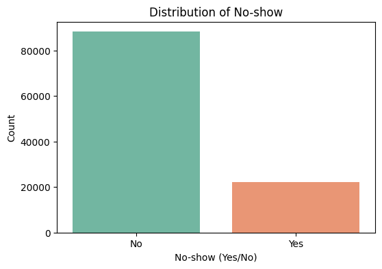

```python
def setup_plot(title='', xlabel='', ylabel='', figsize=(8, 5)):
    """Reusable plot setup for consistent styling."""
    plt.figure(figsize=figsize)
    plt.title(title)
    plt.xlabel(xlabel)
    plt.ylabel(ylabel)
    plt.grid(True)

# Plotting the distribution of No-show
setup_plot("Distribution of No-show", "No-show (Yes/No)", "Count", figsize=(6, 4))
sns.countplot(x='No-show', data=df, palette="Set2")
plt.show()
```

### Distribution of No-show

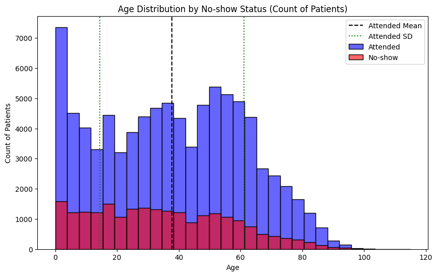

```python
# Create histograms for Age vs. No-show

setup_plot("Age Distribution by No-show Status (Count of Patients)", "Age", "Count of Patients", figsize=(10, 6))

# Histogram for patients who attended (No-show == 'No')
sns.histplot(df[df['No-show'] == 'No']['Age'], color='blue', label='Attended', bins=30, alpha=0.6)

# Histogram for patients who did not attend (No-show == 'Yes')
sns.histplot(df[df['No-show'] == 'Yes']['Age'], color='red', label='No-show', bins=30, alpha=0.6)

# Calculate mean and standard deviation using NumPy
mean_age = np.mean(df[df['No-show'] == 'No']['Age'])
std_age = np.std(df[df['No-show'] == 'No']['Age'], ddof=1)

# Plot mean and standard deviation lines
plt.axvline(mean_age, color='black', linestyle='--', label='Attended Mean')
plt.axvline(mean_age + std_age, color='green', linestyle=':', label='Attended SD')
plt.axvline(mean_age - std_age, color='green', linestyle=':')
plt.legend()
plt.show()
```

### Age Distribution by No-show Status

This plot compares the **age distribution** for patients who attended their appointments (**blue**) and those who missed them (**red**). I also added vertical lines representing the **mean age** (black dashed line) and **one standard deviation** above and below the mean (green dotted lines) for the attended group.

This analysis helps to understand how **age** may influence the likelihood of attending or missing an appointment.

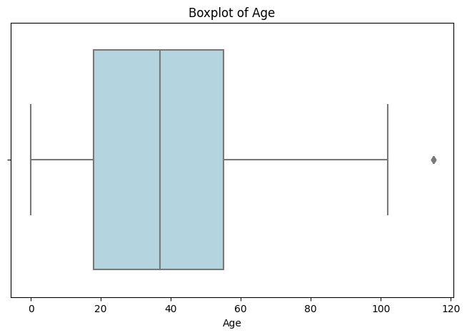

```python
setup_plot("Boxplot of Age", "Age", "", figsize=(8, 5))
sns.boxplot(x=df['Age'], color="lightblue")
plt.show()
```

- The box represents the **interquartile range (IQR)** (25th to 75th percentile).
- The line inside the box is the **median age**.
- The whiskers extend to **1.5 times the IQR**.
- Any points outside the whiskers are **potential outliers**, which may indicate extreme values in the dataset.

## Conclusions

### **Data Wrangling**

- Cleaned and optimized data by fixing types, handling incorrect values, and converting categorical variables.

### **Key Takeaways**

- No-shows are a significant issue.
- Age plays a role in appointment attendance.
- Data is now ready for deeper analysis.

```python
# Running this cell will execute a bash command to convert this notebook to an .html file
!python -m nbconvert --to html Investigate_a_Dataset.ipynb
```